# Case Study: How Does a Bike-Share Navigate Speedy Success?

Trinh Flynt

1/31/2022

## The Scenario

You are a junior data analyst working in the marketing analyst team at Cyclistic, a fictional bike-share company in Chicago. The director of marketing believes the company’s future success depends on maximizing the number of annual memberships. Therefore, your team wants to understand how casual riders and annual members use Cyclistic bikes differently. From these insights, your team will design a new marketing strategy to convert casual riders into annual members. But first, Cyclistic executives must approve your recommendations, so they must be backed up with compelling data insights and professional data visualizations.

## Business Task

Analyze historical data to understand how annual members and casual riders use Cyclistic bikes differently as well as identify which factors might influence casual riders to become members.

## Prepare

Cyclistic’s historical trip data has been made available by Motivate International Inc. under this [license](https://ride.divvybikes.com/data-license-agreement) and can be downloaded [here](https://divvy-tripdata.s3.amazonaws.com/index.html). 12 months of Cyclistic trip data (01/2021-12/2021) was used to analyze and identify trends.

The datasets have a different name because Cyclistic is a fictional company. For the purposes of this case study, the datasets are considered to be appropriate to answer the business questions. This is public data that can be used to explore how different customer types are using Cyclistic bikes. But we won’t be able to connect pass purchases to credit card numbers to determine if casual riders live in the Cyclistic service area or if they have purchased multiple single passes due to data-privacy issues.

## Process

### Step 1: Loading packages

```r
library(tidyverse)
library(skimr)
library(janitor)
library(tidyr)
library(lubridate)
```

```r
library(ggplot2)
library(gridExtra)
```

### Step 2: Importing data

#### Importing data

```r
jan2021_trips <- read.csv("202101-divvy-tripdata.csv", na.strings = c(""))
feb2021_trips <- read.csv("202102-divvy-tripdata.csv", na.strings = c(""))
mar2021_trips <- read.csv("202103-divvy-tripdata.csv", na.strings = c(""))
apr2021_trips <- read.csv("202104-divvy-tripdata.csv", na.strings = c(""))
may2021_trips <- read.csv("202105-divvy-tripdata.csv", na.strings = c(""))
jun2021_trips <- read.csv("202106-divvy-tripdata.csv", na.strings = c(""))
jul2021_trips <- read.csv("202107-divvy-tripdata.csv", na.strings = c(""))
aug2021_trips <- read.csv("202108-divvy-tripdata.csv", na.strings = c(""))
sep2021_trips <- read.csv("202109-divvy-tripdata.csv", na.strings = c(""))
oct2021_trips <- read.csv("202110-divvy-tripdata.csv", na.strings = c(""))
nov2021_trips <- read.csv("202111-divvy-tripdata.csv", na.strings = c(""))
dec2021_trips <- read.csv("202112-divvy-tripdata.csv", na.strings = c(""))
```

#### Comparing datasets to check if they will successfully bind together by rows

```r
mismatch <- compare_df_cols(jan2021_trips, feb2021_trips, mar2021_trips, apr2021_trips, may2021_trips, jun2021_trips, jul2021_trips, aug2021_trips, sep2021_trips, oct2021_trips, nov2021_trips, dec2021_trips, return = "mismatch")
if (dim(mismatch)[1] == 0){
  print("No mismatch found.")
}else{
  print("Mismatch found. Please verify your data.")
  }
```

```
## [1] "No mismatch found."
```

#### Combining all datasets into one

```r
tripdata <- bind_rows(jan2021_trips, feb2021_trips, mar2021_trips, apr2021_trips, may2021_trips, jun2021_trips, jul2021_trips, aug2021_trips, sep2021_trips, oct2021_trips, nov2021_trips, dec2021_trips)
```

#### Checking if the number of rows in the final dataset matches the total number of rows in all combined datasets

```r
total_rows <- nrow(jan2021_trips) + nrow(feb2021_trips) + nrow(mar2021_trips) + nrow(apr2021_trips) + nrow(may2021_trips) + nrow(jun2021_trips) + nrow(jul2021_trips) + nrow(aug2021_trips) + nrow(sep2021_trips) + nrow(oct2021_trips) + nrow(nov2021_trips) + nrow(dec2021_trips)

if (nrow(tripdata) == total_rows){
  print("Data biding completed!")
}else{
  print("Error! Please verify your data.")
      }
```

```
## [1] "Data biding completed!"
```

### Step 3: Gettting to know your data

#### Loading the first 5 rows of the dataset

```r
head(tripdata, 5)
```

```
##            ride_id rideable_type          started_at            ended_at
## 1 E19E6F1B8D4C42ED electric_bike 2021-01-23 16:14:19 2021-01-23 16:24:44
## 2 DC88F20C2C55F27F electric_bike 2021-01-27 18:43:08 2021-01-27 18:47:12
## 3 EC45C94683FE3F27 electric_bike 2021-01-21 22:35:54 2021-01-21 22:37:14
## 4 4FA453A75AE377DB electric_bike 2021-01-07 13:31:13 2021-01-07 13:42:55
## 5 BE5E8EB4E7263A0B electric_bike 2021-01-23 02:24:02 2021-01-23 02:24:45
##           start_station_name start_station_id end_station_name end_station_id
## 1 California Ave & Cortez St            17660             <NA>           <NA>
## 2 California Ave & Cortez St            17660             <NA>           <NA>
## 3 California Ave & Cortez St            17660             <NA>           <NA>
## 4 California Ave & Cortez St            17660             <NA>           <NA>
## 5 California Ave & Cortez St            17660             <NA>           <NA>
##   start_lat start_lng end_lat end_lng member_casual
## 1  41.90034 -87.69674   41.89  -87.72        member
## 2  41.90033 -87.69671   41.90  -87.69        member
## 3  41.90031 -87.69664   41.90  -87.70        member
## 4  41.90040 -87.69666   41.92  -87.69        member
## 5  41.90033 -87.69670   41.90  -87.70        casual
```

#### Checking the names of the columns in the dataset

```r
colnames(tripdata)
```

```
##  [1] "ride_id"            "rideable_type"      "started_at"
##  [4] "ended_at"           "start_station_name" "start_station_id"
##  [7] "end_station_name"   "end_station_id"     "start_lat"
## [10] "start_lng"          "end_lat"            "end_lng"
## [13] "member_casual"
```

#### Summarizing the data with the ‘str’ and ‘skim_without_charts’ function

```r
str(tripdata)
```

```
## 'data.frame':    5595063 obs. of  13 variables:
##  $ ride_id           : chr  "E19E6F1B8D4C42ED" "DC88F20C2C55F27F" "EC45C94683FE3F27" "4FA453A75AE377DB" ...
##  $ rideable_type     : chr  "electric_bike" "electric_bike" "electric_bike" "electric_bike" ...
##  $ started_at        : chr  "2021-01-23 16:14:19" "2021-01-27 18:43:08" "2021-01-21 22:35:54" "2021-01-07 13:31:13" ...
##  $ ended_at          : chr  "2021-01-23 16:24:44" "2021-01-27 18:47:12" "2021-01-21 22:37:14" "2021-01-07 13:42:55" ...
##  $ start_station_name: chr  "California Ave & Cortez St" "California Ave & Cortez St" "California Ave & Cortez St" "California Ave & Cortez St" ...
##  $ start_station_id  : chr  "17660" "17660" "17660" "17660" ...
##  $ end_station_name  : chr  NA NA NA NA ...
##  $ end_station_id    : chr  NA NA NA NA ...
##  $ start_lat         : num  41.9 41.9 41.9 41.9 41.9 ...
##  $ start_lng         : num  -87.7 -87.7 -87.7 -87.7 -87.7 ...
##  $ end_lat           : num  41.9 41.9 41.9 41.9 41.9 ...
##  $ end_lng           : num  -87.7 -87.7 -87.7 -87.7 -87.7 ...
##  $ member_casual     : chr  "member" "member" "member" "member" ...
```

```r
skim_without_charts(tripdata)
```

Data summary

| Name | tripdata |
| --- | --- |
| Number of rows | 5595063 |
| Number of columns | 13 |
| _______________________ |  |
| Column type frequency: |  |
| character | 9 |
| numeric | 4 |
| ________________________ |  |
| Group variables | None |

**Variable type: character**

| skim_variable | n_missing | complete_rate | min | max | empty | n_unique | whitespace |
| --- | --- | --- | --- | --- | --- | --- | --- |
| ride_id | 0 | 1.00 | 16 | 16 | 0 | 5595063 | 0 |
| rideable_type | 0 | 1.00 | 11 | 13 | 0 | 3 | 0 |
| started_at | 0 | 1.00 | 19 | 19 | 0 | 4677998 | 0 |
| ended_at | 0 | 1.00 | 19 | 19 | 0 | 4671372 | 0 |
| start_station_name | 690809 | 0.88 | 3 | 53 | 0 | 847 | 0 |
| start_station_id | 690806 | 0.88 | 3 | 36 | 0 | 834 | 0 |
| end_station_name | 739170 | 0.87 | 10 | 53 | 0 | 844 | 0 |
| end_station_id | 739170 | 0.87 | 3 | 36 | 0 | 832 | 0 |
| member_casual | 0 | 1.00 | 6 | 6 | 0 | 2 | 0 |

**Variable type: numeric**

| skim_variable | n_missing | complete_rate | mean | sd | p0 | p25 | p50 | p75 | p100 |
| --- | --- | --- | --- | --- | --- | --- | --- | --- | --- |
| start_lat | 0 | 1 | 41.90 | 0.05 | 41.64 | 41.88 | 41.90 | 41.93 | 42.07 |
| start_lng | 0 | 1 | -87.65 | 0.03 | -87.84 | -87.66 | -87.64 | -87.63 | -87.52 |
| end_lat | 4771 | 1 | 41.90 | 0.05 | 41.39 | 41.88 | 41.90 | 41.93 | 42.17 |
| end_lng | 4771 | 1 | -87.65 | 0.03 | -88.97 | -87.66 | -87.64 | -87.63 | -87.49 |

### Step 4: Cleaning & manipulating data

#### Checking duplicates

Based on the data summary, no duplicates found in ‘ride_ids’ column since the number of unique ride_ids equals the number of observations in the dataset.

#### Converting ‘started_at’ and ‘ended_at’ into Datetime from Character

```r
tripdata$started_at <- ymd_hms(tripdata$started_at)
tripdata$ended_at <- ymd_hms(tripdata$ended_at)
```

#### Adding new variables (month, day_of_week, hour_of_day, ride_length) for analysis

```r
tripdata <- tripdata %>%
  mutate(
    month = months(started_at),
    day_of_week = weekdays(started_at),
    hour_of_day = as.character(hour(started_at)),
    ride_length = round(as.numeric(ended_at - started_at)/60, digits = 2)
)
```

#### Previewing the data with ‘skim’ function

```r
skim(tripdata)
```

Data summary

| Name | tripdata |
| --- | --- |
| Number of rows | 5595063 |
| Number of columns | 17 |
| _______________________ |  |
| Column type frequency: |  |
| character | 10 |
| numeric | 5 |
| POSIXct | 2 |
| ________________________ |  |
| Group variables | None |

**Variable type: character**

| skim_variable | n_missing | complete_rate | min | max | empty | n_unique | whitespace |
| --- | --- | --- | --- | --- | --- | --- | --- |
| ride_id | 0 | 1.00 | 16 | 16 | 0 | 5595063 | 0 |
| rideable_type | 0 | 1.00 | 11 | 13 | 0 | 3 | 0 |
| start_station_name | 690809 | 0.88 | 3 | 53 | 0 | 847 | 0 |
| start_station_id | 690806 | 0.88 | 3 | 36 | 0 | 834 | 0 |
| end_station_name | 739170 | 0.87 | 10 | 53 | 0 | 844 | 0 |
| end_station_id | 739170 | 0.87 | 3 | 36 | 0 | 832 | 0 |
| member_casual | 0 | 1.00 | 6 | 6 | 0 | 2 | 0 |
| month | 0 | 1.00 | 3 | 9 | 0 | 12 | 0 |
| day_of_week | 0 | 1.00 | 6 | 9 | 0 | 7 | 0 |
| hour_of_day | 0 | 1.00 | 1 | 2 | 0 | 24 | 0 |

**Variable type: numeric**

| skim_variable | n_missing | complete_rate | mean | sd | p0 | p25 | p50 | p75 | p100 | hist |
| --- | --- | --- | --- | --- | --- | --- | --- | --- | --- | --- |
| start_lat | 0 | 1 | 41.90 | 0.05 | 41.64 | 41.88 | 41.90 | 41.93 | 42.07 | ▁▁▇▇▁ |
| start_lng | 0 | 1 | -87.65 | 0.03 | -87.84 | -87.66 | -87.64 | -87.63 | -87.52 | ▁▁▆▇▁ |
| end_lat | 4771 | 1 | 41.90 | 0.05 | 41.39 | 41.88 | 41.90 | 41.93 | 42.17 | ▁▁▁▇▁ |
| end_lng | 4771 | 1 | -87.65 | 0.03 | -88.97 | -87.66 | -87.64 | -87.63 | -87.49 | ▁▁▁▁▇ |
| ride_length | 0 | 1 | 21.94 | 178.33 | -58.03 | 6.75 | 12.00 | 21.78 | 55944.15 | ▇▁▁▁▁ |

**Variable type: POSIXct**

| skim_variable | n_missing | complete_rate | min | max | median | n_unique |
| --- | --- | --- | --- | --- | --- | --- |
| started_at | 0 | 1 | 2021-01-01 00:02:05 | 2021-12-31 23:59:48 | 2021-08-01 01:52:11 | 4677998 |
| ended_at | 0 | 1 | 2021-01-01 00:08:39 | 2022-01-03 17:32:18 | 2021-08-01 02:21:55 | 4671372 |

- Mean of ride_length: 21.9 minutes.
- Max ride_length: 55,944 minutes.
- Min of ride_length: -58 minutes.

#### Removing observations with ride_length <= 0

```r
tripdata <- filter(tripdata, ride_length > 0)
```

## Analyze & Share

### Number of rides and ride length distribution by user type

```r
# Calculate average ride length by user type
avg <- tripdata %>%
  group_by(member_casual) %>%
  summarise(avg = mean(ride_length))
```

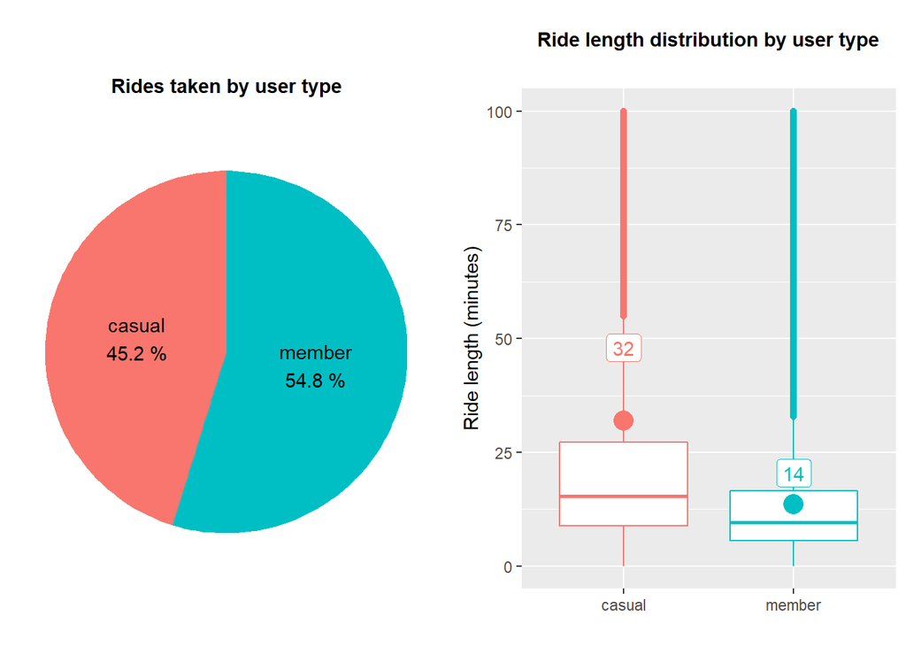

```r
p1 <- tripdata %>%
  group_by(member_casual) %>%
  count() %>%
  ungroup() %>%
  mutate(percentage = round(n/sum(n),4)*100,
         label = paste(member_casual, "\n", paste(percentage, "%"), sep = "")) %>%
  ggplot(aes(x = "", y = n, fill = member_casual)) +
  geom_bar(stat = "identity") +
  geom_text(aes(label = label), position = position_stack(vjust = 0.5)) +
  coord_polar(theta = 'y') +
  theme_void() +
  theme(legend.position = "none", plot.title = element_text(face = "bold", size = 11, hjust = 0.5),
        plot.subtitle = element_text(face = "italic", hjust = 0.5)) +
  labs(title = "Rides taken by user type", subtitle = "")


p2 <- ggplot(data = tripdata,
       mapping = aes(x = member_casual, y = ride_length, color = member_casual)) +
  geom_boxplot() +
  labs(x = "", y = "Ride length (minutes)", title = "\nRide length distribution by user type",
  subtitle = "") +
  theme(legend.position = "none", plot.title = element_text(face = "bold", size = 11, hjust = 0.5),
        plot.subtitle = element_text(face = "italic", hjust = 0.5)) +
  geom_point(data = avg, aes(x = member_casual, y = avg), size = 5) +
  geom_label(data = avg, aes(x = member_casual, y = avg*1.5, label = round(avg, 0))) +
  ylim(0, 100)

grid.arrange(p1, p2, ncol = 2);
```

More than a half of rides are completed by members. However, the average ride length of casual riders (32 mins) is more than double that of members (14 mins). This is possibly because members use the bikes just to commute, while casual riders use them for leisure.

### Bike usage by month

```r
# Sorting data by month
tripdata$month <- ordered(tripdata$month, levels = c("January", "February", "March", "April", "May", "June", "July", "August", "September", "October", "November", "December"))
```

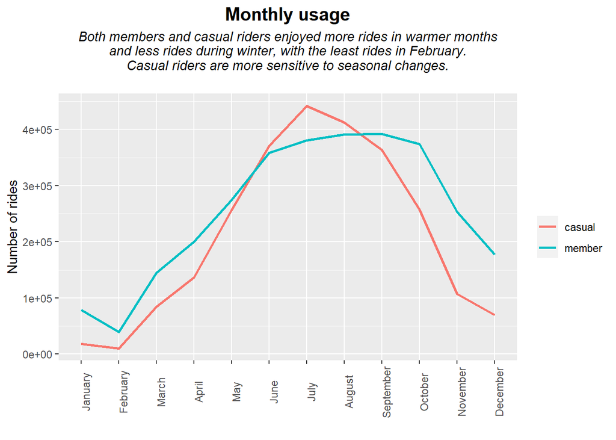

```r
ggplot(tripdata %>% count(member_casual, month),
       aes(x = month, y = n, group = member_casual, color = member_casual)) +
  geom_line(size = 1) +
  labs(x ="", y = "Number of rides", color = "",
       title="Monthly usage",
       subtitle = "Both members and casual riders enjoyed more rides in warmer months\nand less rides during winter, with the least rides in February.\nCasual riders are more sensitive to seasonal changes.\n") +
  scale_y_continuous(labels = function(x) format(x, big.mark = ",")) +
  theme(legend.position = "right", plot.title = element_text(face = "bold", size = 15, hjust = 0.5),
        plot.subtitle = element_text(face = "italic", hjust = 0.5),
        axis.text.x = element_text(angle = 90))
```

### Bike usage by weekday

```r
# Sorting data by weekday and hour of day
tripdata$day_of_week <- ordered(tripdata$day_of_week, levels = c("Sunday", "Monday", "Tuesday", "Wednesday", "Thursday", "Friday", "Saturday"))
tripdata$hour_of_day <- ordered(tripdata$hour_of_day, levels = c("0", "1", "2", "3", "4", "5", "6", "7", "8", "9", "10", "11", "12", "13", "14", "15", "16", "17", "18", "19", "20", "21", "22", "23"))
```

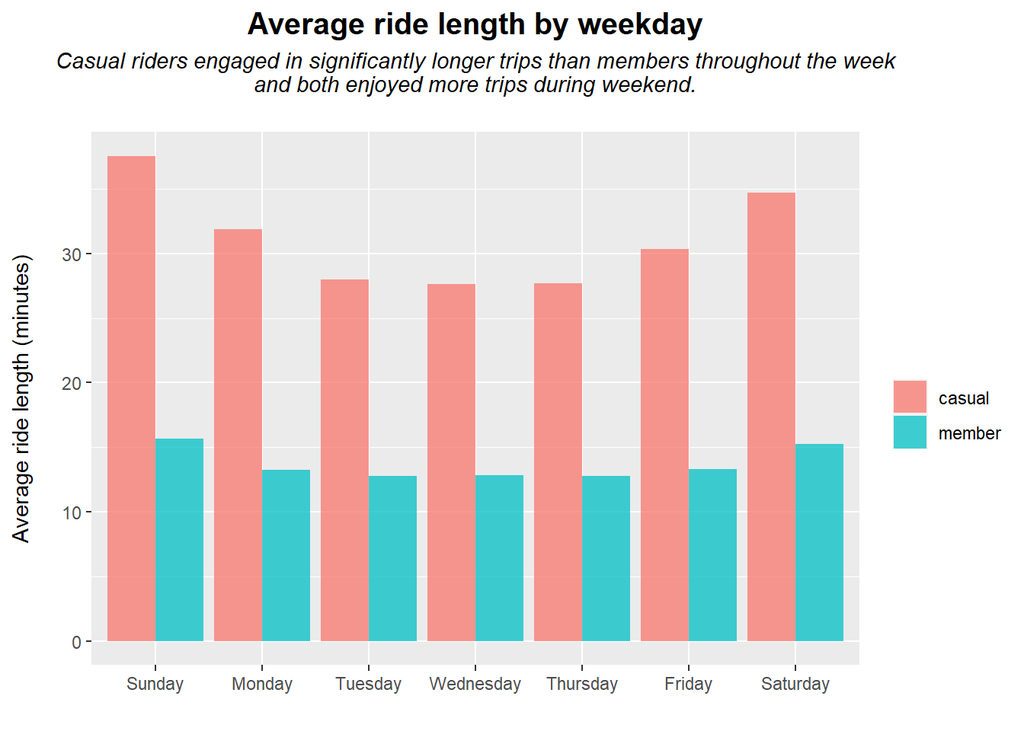

```r
tripdata %>%
  group_by(member_casual, day_of_week) %>%
  summarise(avg_ride_length = mean(ride_length)) %>%
  ggplot(aes(x = day_of_week, y = avg_ride_length, fill = member_casual)) +
  geom_bar(stat = "identity", position = position_dodge(), alpha = 0.75)  +
  labs(x = "", y = "Average ride length (minutes)\n", fill = "",
       title = "Average ride length by weekday", subtitle = "Casual riders engaged in significantly longer trips than members throughout the week\nand both enjoyed more trips during weekend.\n") +
  theme(plot.title = element_text(face = "bold", size = 15, hjust = 0.5),
        plot.subtitle = element_text(face = "italic", hjust = 0.5))
```

### Bike usage during the course of day

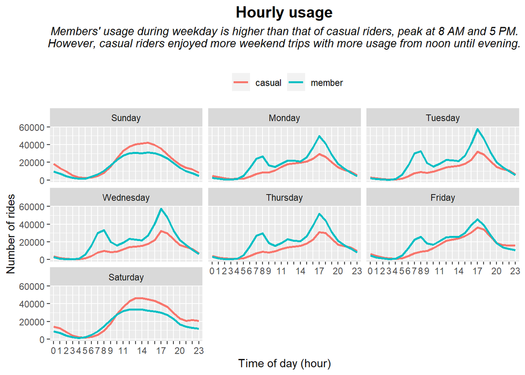

```r
ggplot(tripdata %>% count(member_casual, day_of_week, hour_of_day), aes(x = hour_of_day, y = n, group = member_casual, color = member_casual)) +
  geom_line(size = 1) +
  facet_wrap(~day_of_week, ncol = 3) +
  labs(x = "Time of day (hour)", y = "Number of rides", color = "",
       title = "Hourly usage", subtitle = "Members' usage during weekday is higher than that of casual riders, peak at 8 AM and 5 PM.\nHowever, casual riders enjoyed more weekend trips with more usage from noon until evening.\n") +
  theme(legend.position = "top", plot.title = element_text(face = "bold", size = 15, hjust = 0.5),
        plot.subtitle = element_text(face = "italic", hjust = 0.5)) +
  scale_x_discrete(guide = guide_axis(check.overlap = TRUE))
```

### Most busiest start stations by user type

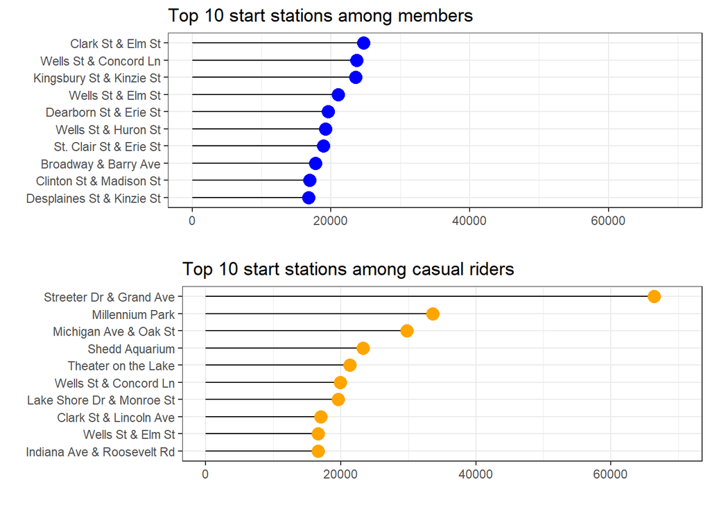

```r
ggp1 <- tripdata %>%
  filter(!is.na(start_station_name), member_casual == "member") %>%
  count(start_station_name) %>%
  arrange(n) %>%# First sort by n. This sort the dataframe but NOT the factor levels
  mutate(start_station_name = factor(start_station_name, levels = start_station_name)) %>%   # This trick update the factor levels
  slice(tail(row_number(), 10)) %>%   # Slice the last 10 rows
  ggplot( aes(x = start_station_name, y = n)) +
    geom_segment( aes(xend = start_station_name, yend=0)) +
    geom_point( size=4, color="blue") +
    labs(x = "", y = "",
       title = "Top 10 start stations among members") +
  theme(plot.title = element_text(face = "bold", size = 8, hjust = 0.5)) +
    ylim(0, 70000) +
    coord_flip() +
    theme_bw()


ggp2 <- tripdata %>%
  filter(!is.na(start_station_name), member_casual == "casual") %>%
  count(start_station_name) %>%
  arrange(n) %>%# First sort by n. This sort the dataframe but NOT the factor levels
  mutate(start_station_name = factor(start_station_name, levels = start_station_name)) %>%   # This trick update the factor levels
  slice(tail(row_number(), 10)) %>%   # Slice the last 10 rows
  ggplot( aes(x = start_station_name, y = n)) +
    geom_segment( aes(xend = start_station_name, yend=0)) +
    geom_point( size=4, color="orange") +
    labs(x = "", y = "",
       title = "Top 10 start stations among casual riders") +
  theme(plot.title = element_text(face = "bold", size = 8, hjust = 0.5)) +
    ylim(0, 70000) +
    coord_flip() +
    theme_bw()

grid.arrange(ggp1, ggp2, ncol = 1)
```

It is interesting to note that Streeter Dr & Grand Ave, Millennium Park and Michigan Ave & Oak St which are located near tourist attractions, are more popular among casual riders than they are among members.

### Bike preference by user type

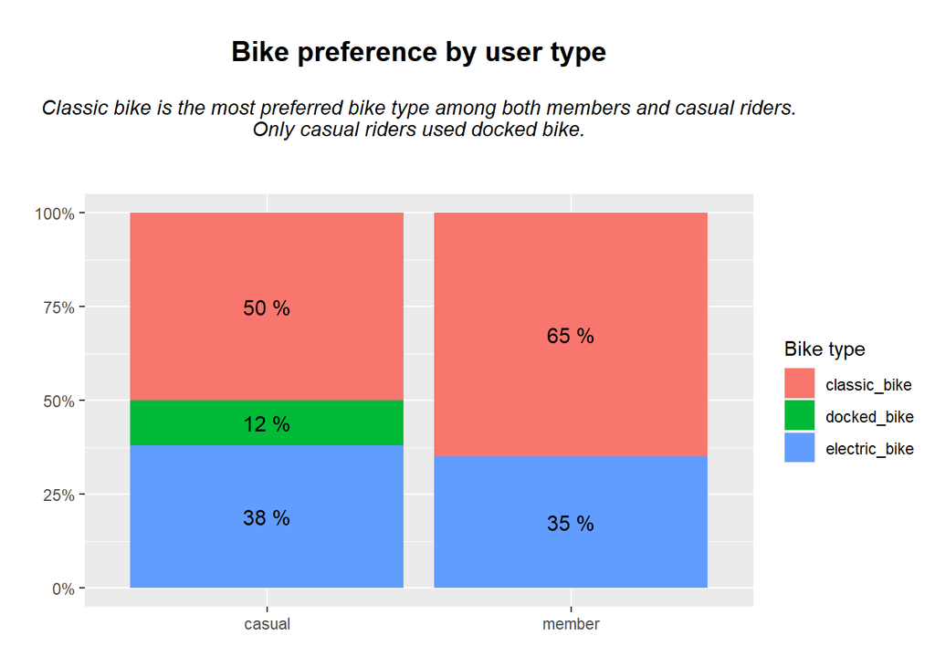

```r
bike_type <- tripdata %>%
  count(member_casual, rideable_type) %>%
  group_by(member_casual) %>%
  mutate(per = round(n/sum(n), 2))

ggplot(filter(bike_type, per > 0), aes(x = member_casual, y = per, fill = rideable_type)) +
  geom_bar(position="fill", stat="identity") +
  labs(x = "", y = "", fill = "Bike type",
       title = "\nBike preference by user type",
       subtitle = "\nClassic bike is the most preferred bike type among both members and casual riders.\nOnly casual riders used docked bike.\n\n") +
  theme(plot.title = element_text(face = "bold", size = 15, hjust = 0.5),
        plot.subtitle = element_text(face = "italic", hjust = 0.5)) +
  scale_y_continuous(labels = scales::percent_format()) +
  geom_text(aes(x = member_casual, y = per, label = paste(per*100, "%"), group = rideable_type), position = position_stack(vjust = .5), size=4)
```

## Recommendations

- As an incentive to get the longer riding and weather-sensitive casual riders to become members, we could introduce a member-only rewards program based on ride length and offer cycling gears such as free water bottles or weatherproof jackets when they sign up to become members.
- Casual riders enjoyed more trips on the weekends where the number of weekend users is significantly higher than those during weekdays. Thus, a weekend membership plan with lower rate for weekday rides is recommended to boost more casual riders to sign up as members and make more trips on weekdays.
- Casual members are likely to use stations near tourist attractions and are more sensitive to weather change. So, advertisements should target users in tourist areas and the marketing campaign should take place in the summer.
- Docked bikes are used only by casual members. Docking stations should be located near popular tourist areas.